# Making Some Graphs

Max Frissell

7/1/2020

### Some Basic Scatterplots from the SRDB Data

#### *They’re all Longitude and Latitude, so they are basically world maps.*

First, here is a plot of all values of the root contribution (RC) to soil respiration (Rs) and where they were taken.

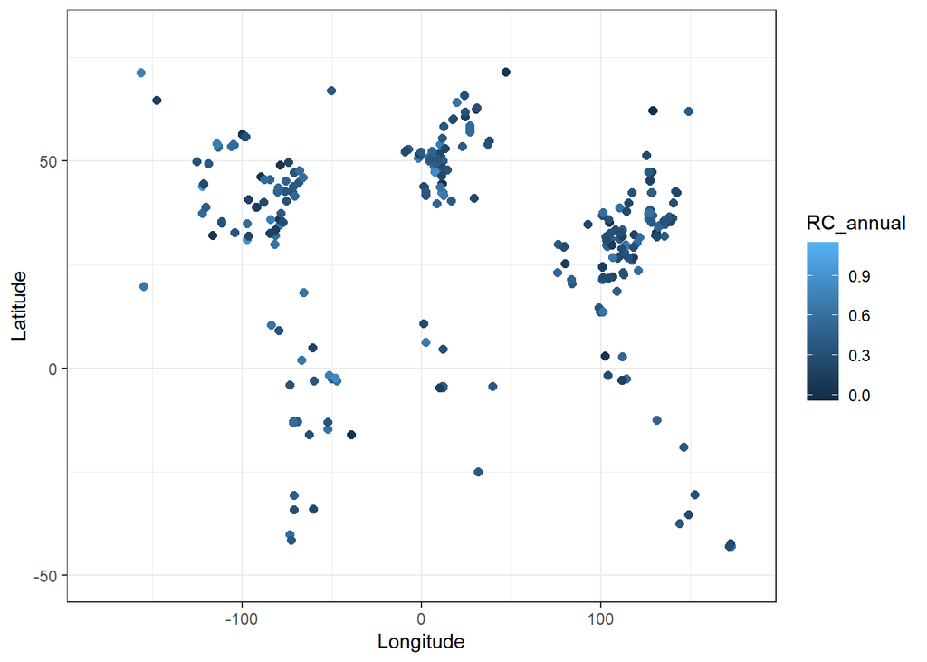

```r
ggplot(RCData, aes(x = Longitude, y = Latitude, col = RC_annual)) +
  geom_point(size = 2) +
  xlim(-180, 180) + ylim(-50, 80) +
  theme_bw()
```

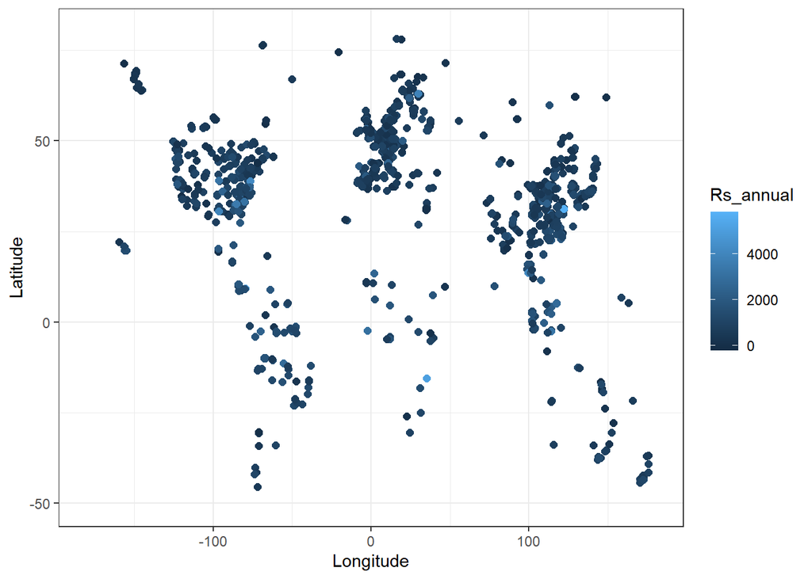

```r
ggplot(allData[Rs_annual <= 6000,], aes(x = Longitude, y = Latitude, col = Rs_annual)) +
  geom_point(size = 2) +
  xlim(-180, 180) + ylim(-50, 80) +
  theme_bw()
```

This is the mean annual temperature (MAT) in degrees Celsius, vs the location.

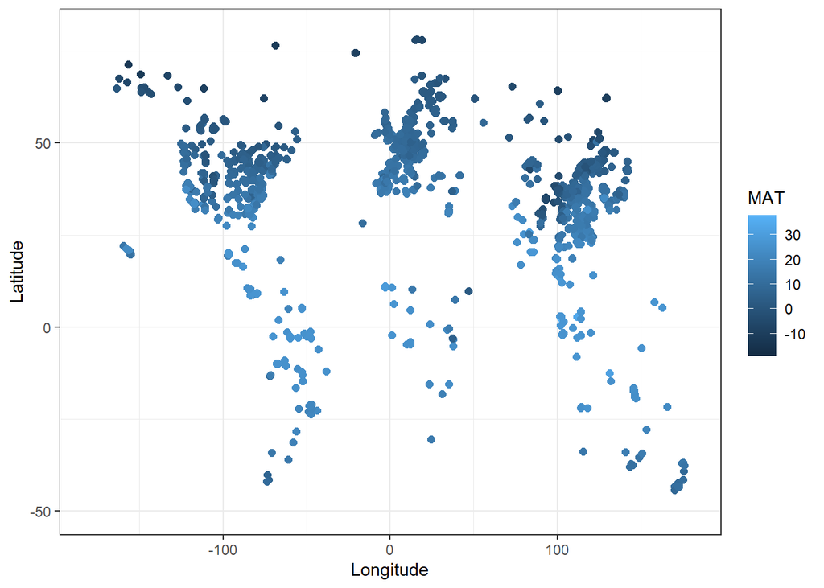

```r
ggplot(allData[MAT >= -20,], aes(x = Longitude, y = Latitude, col = MAT)) +
  geom_point(size = 2) +
  xlim(-180, 180) + ylim(-50, 80) +
  theme_bw()
```

Similarly, this is the mean annual precipitation (MAP) in millimeters.

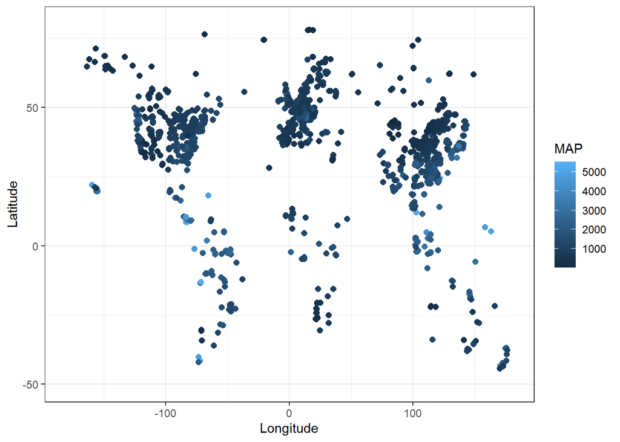

```r
ggplot(allData[MAP >= 0,], aes(x = Longitude, y = Latitude, col = MAP)) +
  geom_point(size = 2) +
  xlim(-180, 180) + ylim(-50, 80) +
  theme_bw()
```

### Histograms of Relevent Data

Now here is the distribution of values in the SRDB for the soil respiration root contribution. The values that are less than 0 or greater than 1 must be wrong because these are proportions.

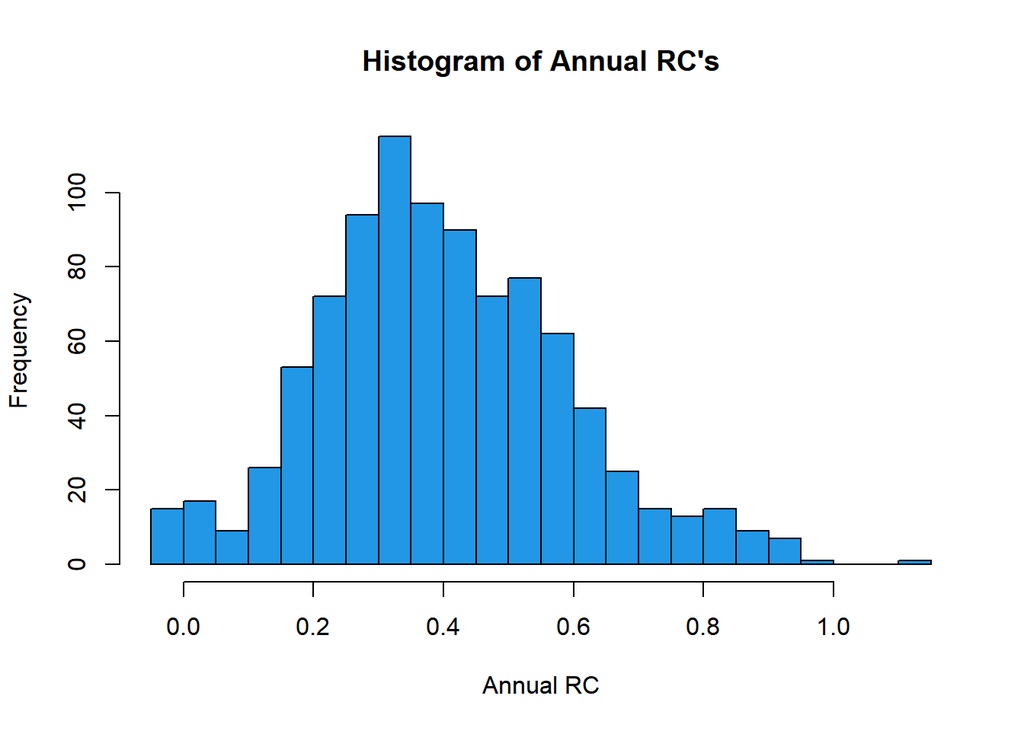

```r
hist(RCData$RC_annual, main = "Histogram of Annual RC's", xlab = "Annual RC", breaks = 20, col = "4") #makes the histogram
```

This is the histogram of annual soil respiration values. There were a few very large outliers that were removed. This kept the maximum x axis value small enough for the histogram to actually have meaning.

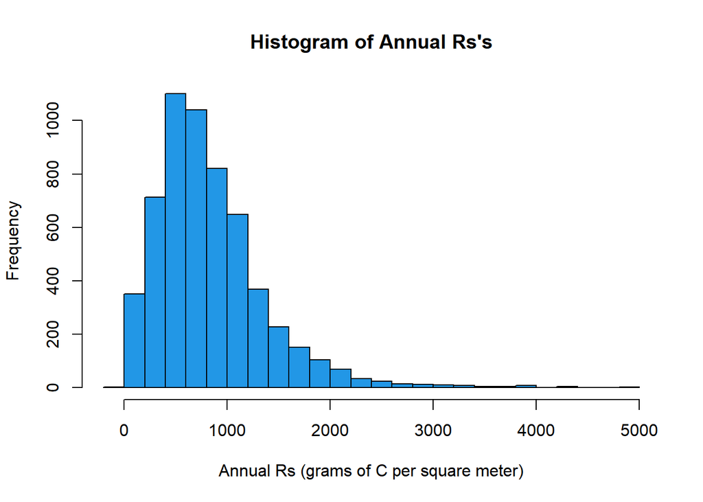

```r
hist(allData$Rs_annual[Rs_annual <= 5000], main = "Histogram of Annual Rs's", xlab = "Annual Rs (grams of C per square meter)", breaks = 20, col = "4") #makes the histogram
```

#### *Doesn’t that just look beautiful! By far my favorite graph here*

This is a histogram of the mean annual temperature values, in degrees Celsius.

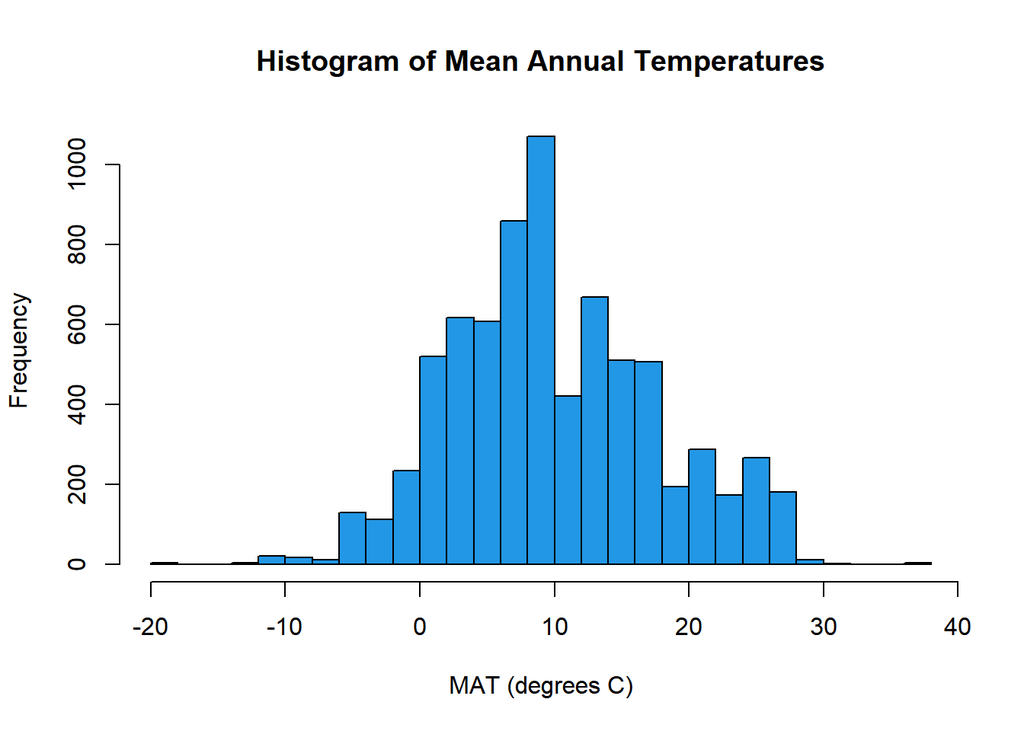

```r
hist(allData$MAT, main = "Histogram of Mean Annual Temperatures",
     xlab = "MAT (degrees C)", breaks = 40, col = "4") #makes the histogram
```

This is a histogram of mean annual precipitation values, in millimeters.

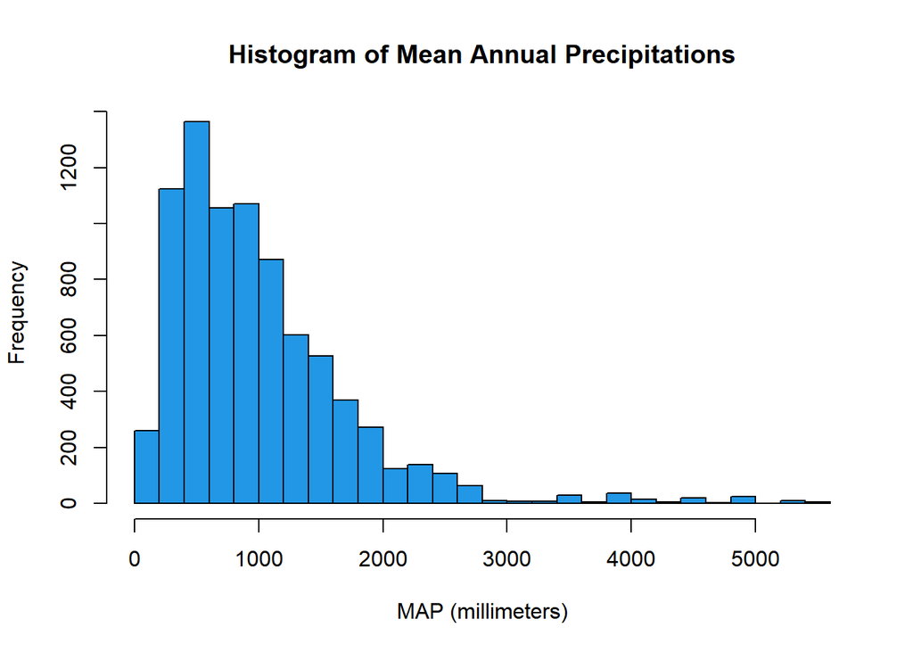

```r
hist(allData$MAP, main = "Histogram of Mean Annual Precipitations",
     xlab = "MAP (millimeters)", breaks = 20, col = "4") #makes the histogram
```

### Now this is just a relationship that I stumbled into and the graph looks cool

This is the relationship between the distance from the equator in degrees and mean annual temperature. Everyone would expect their to be a relationship, but it turned out pretty well and I just like how the graph looks.

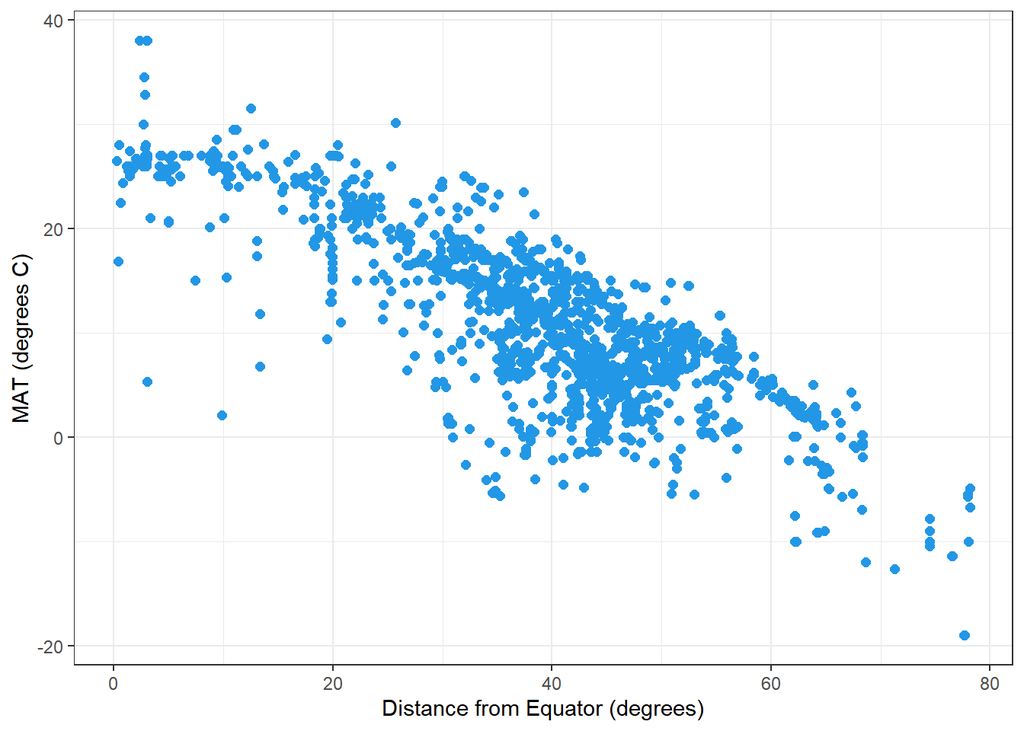

```r
ggplot(allData[MAT >= -20,], aes(x = abs(Latitude), y = MAT)) +
  geom_point(color = "4", size = 2) +
  theme_bw() +
  labs(x = "Distance from Equator (degrees)", y = "MAT (degrees C)")
```

That was fun.